# PML-writeup

Caroliem

Sunday, January 18, 2015

## introduction & summary

This report predict the manner in which person performed their exercise, using data from accelerometers on the belt, forearm, arm, and dumbell of 6 participants. The data for this project come from this source: http://groupware.les.inf.puc-rio.br/har.

## Data loading and analysis

First loading required packages and data.

```r
library(caret)
```

Then load data and do some exploratory data analysis. The files can be downloaded from: - https://d396qusza40orc.cloudfront.net/predmachlearn/pml-training.csv for training - https://d396qusza40orc.cloudfront.net/predmachlearn/pml-testing.csv for testing.

```r
train <- read.csv('pml-training.csv' , na.strings=c("NA",""))
test <- read.csv('pml-testing.csv' , na.strings=c("NA",""))

## explorary data analysis
str(train)
```

```
## 'data.frame':    19622 obs. of  160 variables:
##  $ X                       : int  1 2 3 4 5 6 7 8 9 10 ...
##  $ user_name               : Factor w/ 6 levels "adelmo","carlitos",..: 2 2 2 2 2 2 2 2 2 2 ...
##  $ raw_timestamp_part_1    : int  1323084231 1323084231 1323084231 1323084232 1323084232 1323084232 1323084232 1323084232 1323084232 1323084232 ...
##  $ raw_timestamp_part_2    : int  788290 808298 820366 120339 196328 304277 368296 440390 484323 484434 ...
##  $ cvtd_timestamp          : Factor w/ 20 levels "02/12/2011 13:32",..: 9 9 9 9 9 9 9 9 9 9 ...
##  $ new_window              : Factor w/ 2 levels "no","yes": 1 1 1 1 1 1 1 1 1 1 ...
##  $ num_window              : int  11 11 11 12 12 12 12 12 12 12 ...
##  $ roll_belt               : num  1.41 1.41 1.42 1.48 1.48 1.45 1.42 1.42 1.43 1.45 ...
##  $ pitch_belt              : num  8.07 8.07 8.07 8.05 8.07 8.06 8.09 8.13 8.16 8.17 ...
##  $ yaw_belt                : num  -94.4 -94.4 -94.4 -94.4 -94.4 -94.4 -94.4 -94.4 -94.4 -94.4 ...
##  $ total_accel_belt        : int  3 3 3 3 3 3 3 3 3 3 ...
##  $ kurtosis_roll_belt      : Factor w/ 396 levels "-0.016850","-0.021024",..: NA NA NA NA NA NA NA NA NA NA ...
##  $ kurtosis_picth_belt     : Factor w/ 316 levels "-0.021887","-0.060755",..: NA NA NA NA NA NA NA NA NA NA ...
##  $ kurtosis_yaw_belt       : Factor w/ 1 level "#DIV/0!": NA NA NA NA NA NA NA NA NA NA ...
```

[output cut: 86 more lines]

```r
str(train$classe)
```

```
##  Factor w/ 5 levels "A","B","C","D",..: 1 1 1 1 1 1 1 1 1 1 ...
```

```r
dim(train)
```

```
## [1] 19622   160
```

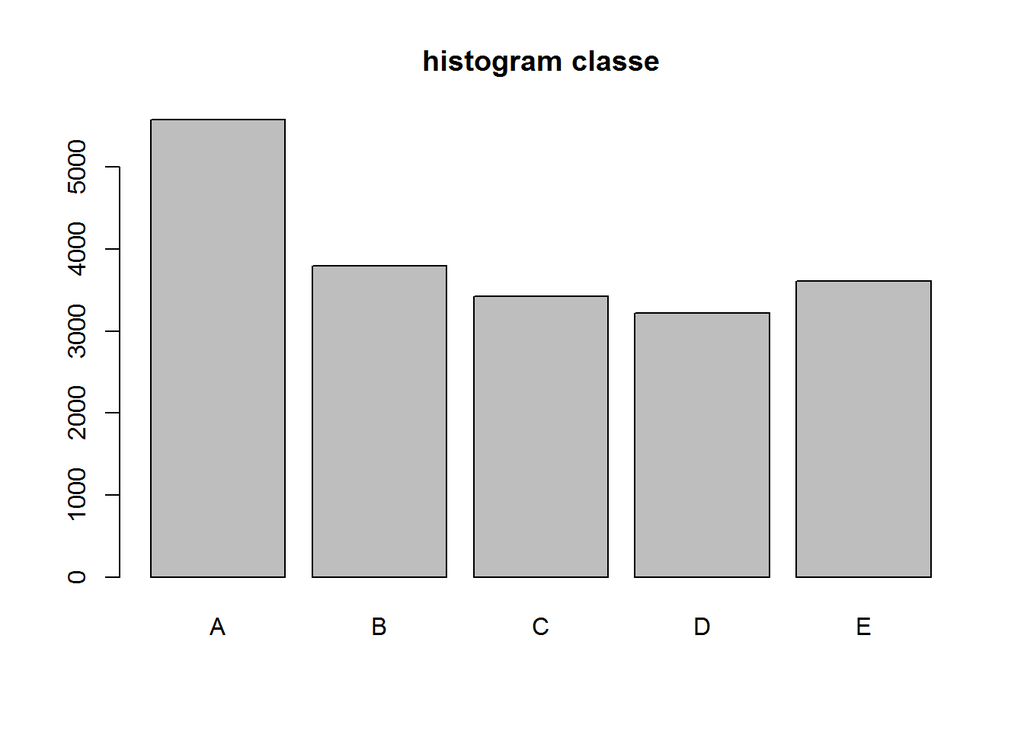

```r
plot(train$classe, main = "histogram classe")
```

As we see there are lots of variabrles with NA’s lets remove those columns with more than 10% NA’s. Also remove columns related to index, username or timestamp

```r
train <- train[,7:160]
test <- test[,7:160]
NoNa <- apply(!is.na(train),2,sum)>(19622-0.1*19622)
train <- train[,NoNa]
test <- test[,NoNa]
dim(train)
```

```
## [1] 19622    54
```

As I was not able to run a mode wit 19622 observation, so for speed I needed to reduced the training set to only include 45%

```r
InTrain <- createDataPartition(y=train$classe, p=0.45,list=FALSE)
trainset <- train[InTrain,]
testset <- train[-InTrain,]
```

For the training we use a 5-fold cross validation. As we already need to reduce the training set, we don’t make k greater than 5, in order to avoid the sample set become to small.

```r
control <- trainControl(method = "cv", number = 5)
```

As boosting and random forest are the most accurate models, we are using both and check accuracy.

```r
#randomforest
set.seed(32333)
fitrf <- train(classe ~  ., data = trainset, method = "rf", proxy=TRUE, trControl=control)
#gbm
set.seed(32333)
fitb <- train(classe ~  ., data = trainset, method = "gbm",  trControl=control,verbose=FALSE)
fitb$finalModel
```

```
## A gradient boosted model with multinomial loss function.
## 150 iterations were performed.
## There were 53 predictors of which 44 had non-zero influence.
```

Let’s compare accuracy of both models:

```r
results <- data.frame(method = c(fitrf$method,fitb$method),
                      accuracy=c( fitrf$results[fitrf$results$mtry %in% fitrf$bestTune,2],
                                  tail(fitb$results[order(fitb$results$Accuracy),],1)$Accuracy)
                      )
results
```

```
##   method  accuracy
## 1     rf 0.9933193
## 2    gbm 0.9840356
```

Accuracy of rf model is better so lets use and view the Random forest model.

```r
fitrf$finalModel
```

```
##
## Call:
##  randomForest(x = x, y = y, mtry = param$mtry, proxy = TRUE)
##                Type of random forest: classification
##                      Number of trees: 500
## No. of variables tried at each split: 27
##
##         OOB estimate of  error rate: 0.51%
## Confusion matrix:
##      A    B    C    D    E  class.error
## A 2510    0    0    0    1 0.0003982477
## B    5 1699    4    1    0 0.0058513751
## C    0    9 1531    0    0 0.0058441558
## D    0    1   13 1433    1 0.0103591160
## E    0    1    0    9 1614 0.0061576355
```

```r
predictionsrf <- predict(fitrf, trainset)
confusionMatrix(predictionsrf ,trainset$classe)
```

```
## Confusion Matrix and Statistics
##
##           Reference
## Prediction    A    B    C    D    E
##          A 2511    0    0    0    0
##          B    0 1709    0    0    0
##          C    0    0 1540    0    0
##          D    0    0    0 1448    0
##          E    0    0    0    0 1624
##
## Overall Statistics
##
##                Accuracy : 1
##                  95% CI : (0.9996, 1)
##     No Information Rate : 0.2843
##     P-Value [Acc > NIR] : < 2.2e-16
##
##                   Kappa : 1
##  Mcnemar's Test P-Value : NA
##
## Statistics by Class:
##
##                      Class: A Class: B Class: C Class: D Class: E
## Sensitivity            1.0000   1.0000   1.0000   1.0000   1.0000
## Specificity            1.0000   1.0000   1.0000   1.0000   1.0000
## Pos Pred Value         1.0000   1.0000   1.0000   1.0000   1.0000
## Neg Pred Value         1.0000   1.0000   1.0000   1.0000   1.0000
## Prevalence             0.2843   0.1935   0.1744   0.1639   0.1839
## Detection Rate         0.2843   0.1935   0.1744   0.1639   0.1839
## Detection Prevalence   0.2843   0.1935   0.1744   0.1639   0.1839
## Balanced Accuracy      1.0000   1.0000   1.0000   1.0000   1.0000
```

As we only used part of the training data set for prediction we can use the other part for testing and estimating the out of sample error.

```r
predictionstest <- predict(fitrf, testset)
confusionMatrix(predictionstest ,testset$classe)
```

```
## Confusion Matrix and Statistics
##
##           Reference
## Prediction    A    B    C    D    E
##          A 3068   11    0    0    0
##          B    1 2073   12    0    1
##          C    0    3 1870   17    0
##          D    0    1    0 1751    7
##          E    0    0    0    0 1975
##
## Overall Statistics
##
##                Accuracy : 0.9951
##                  95% CI : (0.9936, 0.9963)
##     No Information Rate : 0.2844
##     P-Value [Acc > NIR] : < 2.2e-16
##
##                   Kappa : 0.9938
##  Mcnemar's Test P-Value : NA
##
## Statistics by Class:
##
##                      Class: A Class: B Class: C Class: D Class: E
## Sensitivity            0.9997   0.9928   0.9936   0.9904   0.9960
## Specificity            0.9986   0.9984   0.9978   0.9991   1.0000
## Pos Pred Value         0.9964   0.9933   0.9894   0.9955   1.0000
## Neg Pred Value         0.9999   0.9983   0.9987   0.9981   0.9991
## Prevalence             0.2844   0.1935   0.1744   0.1639   0.1838
## Detection Rate         0.2843   0.1921   0.1733   0.1623   0.1830
## Detection Prevalence   0.2854   0.1934   0.1752   0.1630   0.1830
## Balanced Accuracy      0.9991   0.9956   0.9957   0.9947   0.9980
```

```r
outOfSampleError <- 1-sum(predictionstest == testset$classe)/length(predictionstest)
print(outOfSampleError)
```

```
## [1] 0.004911956
```